# Regression and model validation

## Data exploration

Read the data

```r
learning2014 <- read.csv("./data/learning2014.csv")
```

For data structure:

```r
dim(learning2014)
```

```
## [1] 166   8
```

```r
str(learning2014)
```

```
## 'data.frame':    166 obs. of  8 variables:
##  $ X       : int  1 2 3 4 5 6 7 8 9 10 ...
##  $ gender  : Factor w/ 2 levels "F","M": 1 2 1 2 2 1 2 1 2 1 ...
##  $ age     : int  53 55 49 53 49 38 50 37 37 42 ...
##  $ attitude: num  3.7 3.1 2.5 3.5 3.7 3.8 3.5 2.9 3.8 2.1 ...
##  $ deep    : num  3.58 2.92 3.5 3.5 3.67 ...
##  $ stra    : num  3.38 2.75 3.62 3.12 3.62 ...
##  $ surf    : num  2.58 3.17 2.25 2.25 2.83 ...
##  $ points  : int  25 12 24 10 22 21 21 31 24 26 ...
```

```r
head(learning2014)
```

```
##   X gender age attitude     deep  stra     surf points
## 1 1      F  53      3.7 3.583333 3.375 2.583333     25
## 2 2      M  55      3.1 2.916667 2.750 3.166667     12
## 3 3      F  49      2.5 3.500000 3.625 2.250000     24
## 4 4      M  53      3.5 3.500000 3.125 2.250000     10
## 5 5      M  49      3.7 3.666667 3.625 2.833333     22
## 6 6      F  38      3.8 4.750000 3.625 2.416667     21
```

Explore the dataset

```r
summary(learning2014)
```

```
##        X          gender       age           attitude          deep
##  Min.   :  1.00   F:110   Min.   :17.00   Min.   :1.400   Min.   :1.583
##  1st Qu.: 42.25   M: 56   1st Qu.:21.00   1st Qu.:2.600   1st Qu.:3.333
##  Median : 83.50           Median :22.00   Median :3.200   Median :3.667
##  Mean   : 83.50           Mean   :25.51   Mean   :3.143   Mean   :3.680
##  3rd Qu.:124.75           3rd Qu.:27.00   3rd Qu.:3.700   3rd Qu.:4.083
##  Max.   :166.00           Max.   :55.00   Max.   :5.000   Max.   :4.917
##       stra            surf           points
##  Min.   :1.250   Min.   :1.583   Min.   : 7.00
##  1st Qu.:2.625   1st Qu.:2.417   1st Qu.:19.00
##  Median :3.188   Median :2.833   Median :23.00
##  Mean   :3.121   Mean   :2.787   Mean   :22.72
##  3rd Qu.:3.625   3rd Qu.:3.167   3rd Qu.:27.75
##  Max.   :5.000   Max.   :4.333   Max.   :33.00
```

## Create a subset

```
library(dplyr)
keep <- c("Country", "Edu2.FM", "Labo.FM", "Life.Exp", "Edu.Exp", "GNI", "Mat.Mor", "Ado.Birth", "Parli.F")
human <- select(human, one_of(keep))
```

## Missing values

In R, NA stands for not available, which means that the data point is missing. If a variable you wish to analyse contains missing values, there are usually two main options:  
1. Remove the observations with missing values  
2. Replace the missing values with actual values using an imputation technique.

Option 1:

```
# print out a completeness indicator of the 'human' data
complete.cases(human)

# print out the data along with a completeness indicator as the last column
data.frame(human[-1], comp = complete.cases(human))

# filter out all rows with NA values
human_ <- filter(human, complete.cases(human))
```

## Excluding observations

```
# look at the last 10 observations of human
tail(human, 10)

# define the last indice we want to keep
last <- nrow(human) - 7

# choose everything until the last 7 observations
human_ <- human[1:last, ]

# add countries as rownames
rownames(human_) <- human_$Country
```

## Graphical exploration

```r
library(GGally)
```

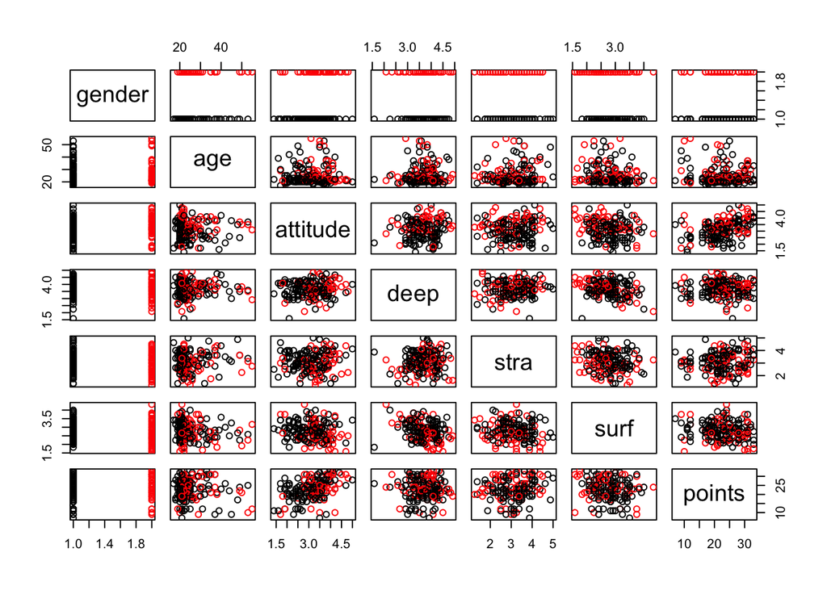

```r
library(ggplot2)
pairs(learning2014[-1], col = learning2014$gender)
```

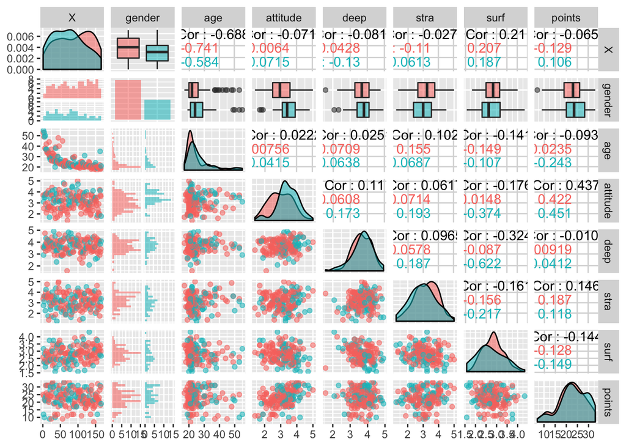

```r
p <- ggpairs(learning2014, mapping = aes(col = gender, alpha = 0.3), lower = list(combo = wrap("facethist", bins = 20)))
p
```

## Probability plots

Before starting any analysis, it is good to look at the probability plots of each variable.

Options:  
1. `qqnorm( )` function to create a Quantile-Quantile plot evaluating the fit of sample data to the normal distribution.  
2. The `fitdistr( )` function in the MASS package provides maximum-likelihood fitting of univariate distributions. The format is `fitdistr(x, densityfunction)` where x is the sample data and density function is one of the following: “beta”, “cauchy”, “chi-squared”, “exponential”, “f”, “gamma”, “geometric”, “log-normal”, “lognormal”, “logistic”, “negative binomial”, “normal”, “Poisson”, “t” or “weibull”.  
3. For other, see: https://cran.r-project.org/doc/contrib/Ricci-distributions-en.pdf

If the distribution does satisfy the normality criterion, log-transform the variable to identify outliers more clearly.  
Delete those observations.  
Try step 1 again.

## Boxplots for numerical variables

```
library(ggplot2)
```

1. Create a dummy variable with the same mean and standard deviation, but normally distributed, for comparison purposes:

   ```
   absences_norm <- rnorm(200,mean=mean(absences, na.rm=TRUE), sd=sd(absences, na.rm=TRUE))
   ```

2. Plot the two variables side by side

   ```
   boxplot(absences, absences_norm, main = "Boxplots of the absences variable: actual distribution vs. normal", at = c(1,2), names = c("absences","absences_norm"), las = 2, col = c("pink","yellow"), horizontal = TRUE)
   ```

## Сorrelation plots

```
library(tidyverse), library(MASS)
```

### Option 1

1. Calculate the correlation matrix and round it (tidyverse and corrplot packages)

   ```
   cor_matrix <- cor(Boston)
   cor_matrix_r <- cor_matrix %>% round(2)
   # округлить до 2 цифр после запятой
   ```

2. Visualize the correlation matrix

   ```
   corrplot(cor_matrix_r, method="circle", type = "upper", cl.pos = "b", tl.pos = "d", tl.cex = 0.6)
   ```

### Option 2

3. Use `pairs()` command (or ggpairs with GGally package)
4. With `pairs()` you can reduce the number of pairs to see the plots more clearly. After the data argument, you have to specify the columns you want to see. Ex.: `pairs(Boston[6:10]), col = km$cluster)`

## Сenter and standardize numerical variables

```
scale()
boston_scaled <- scale(Boston), # mean = 0, центрирует вокруг нуля
class(boston_scaled) # в результате шкалирования получается матрица
boston_scaled <- as.data.frame(boston_scaled) # меняем матрицу на data frame
```

## Create a categorical variable form a numerical one

*Quantiles*  
1. Create a quantile vector of crim and print it

```
bins <- quantile(boston_scaled$crim)
bins
```

2. Create a categorical variable ‘crime’

   ```
   crime <- cut(boston_scaled$crim, breaks = bins, include.lowest = TRUE, label = c("low","med_low","med_high","high"))
   ```

3. Look at the table of the new factor crime

   ```
   table(crime)
   ```

4. Remove original crim from the dataset

   ```
   boston_scaled <- dplyr::select(boston_scaled, -crim)
   ```

5. Add the new categorical value to scaled data

   ```
   boston_scaled <- data.frame(boston_scaled, crime)
   ```

## Linear regression

We are now interested in exploring whether we can explain the student exam grade by relating it with other available variables. A multiple regression model is fitted with a response variable ‘points’ and explanatory variables ‘attitude’, ‘stra’ and ‘surf’.

```r
lm <- lm(points ~ attitude + stra + surf, data = learning2014)
lm
```

```
##
## Call:
## lm(formula = points ~ attitude + stra + surf, data = learning2014)
##
## Coefficients:
## (Intercept)     attitude         stra         surf
##     11.0171       3.3952       0.8531      -0.5861
```

```r
summary(lm)
```

```
##
## Call:
## lm(formula = points ~ attitude + stra + surf, data = learning2014)
##
## Residuals:
##      Min       1Q   Median       3Q      Max
## -17.1550  -3.4346   0.5156   3.6401  10.8952
##
## Coefficients:
##             Estimate Std. Error t value Pr(>|t|)
## (Intercept)  11.0171     3.6837   2.991  0.00322 **
## attitude      3.3952     0.5741   5.913 1.93e-08 ***
## stra          0.8531     0.5416   1.575  0.11716
## surf         -0.5861     0.8014  -0.731  0.46563
## ---
## Signif. codes:  0 '***' 0.001 '**' 0.01 '*' 0.05 '.' 0.1 ' ' 1
##
## Residual standard error: 5.296 on 162 degrees of freedom
## Multiple R-squared:  0.2074, Adjusted R-squared:  0.1927
## F-statistic: 14.13 on 3 and 162 DF,  p-value: 3.156e-08
```

The model with three explanatory variables is able to account for 21% of the variance (multiple R squared). It shows that the only variable with a statistically significant relationship with examn grade is ‘attitude’. Now we have to try out and take the two other factors one by one in a search of a more parsimonious model.

```r
lm1 <- lm(points ~ attitude + stra, data = learning2014)
lm1
```

```
##
## Call:
## lm(formula = points ~ attitude + stra, data = learning2014)
##
## Coefficients:
## (Intercept)     attitude         stra
##      8.9729       3.4658       0.9137
```

```r
summary(lm1)
```

```
##
## Call:
## lm(formula = points ~ attitude + stra, data = learning2014)
##
## Residuals:
##      Min       1Q   Median       3Q      Max
## -17.6436  -3.3113   0.5575   3.7928  10.9295
##
## Coefficients:
##             Estimate Std. Error t value Pr(>|t|)
## (Intercept)   8.9729     2.3959   3.745  0.00025 ***
## attitude      3.4658     0.5652   6.132 6.31e-09 ***
## stra          0.9137     0.5345   1.709  0.08927 .
## ---
## Signif. codes:  0 '***' 0.001 '**' 0.01 '*' 0.05 '.' 0.1 ' ' 1
##
## Residual standard error: 5.289 on 163 degrees of freedom
## Multiple R-squared:  0.2048, Adjusted R-squared:  0.1951
## F-statistic: 20.99 on 2 and 163 DF,  p-value: 7.734e-09
```

```r
lm2 <- lm(points ~ attitude + surf, data = learning2014)
lm2
```

```
##
## Call:
## lm(formula = points ~ attitude + surf, data = learning2014)
##
## Coefficients:
## (Intercept)     attitude         surf
##      14.120        3.426       -0.779
```

```r
summary(lm2)
```

```
##
## Call:
## lm(formula = points ~ attitude + surf, data = learning2014)
##
## Residuals:
##     Min      1Q  Median      3Q     Max
## -17.277  -3.236   0.386   3.977  10.642
##
## Coefficients:
##             Estimate Std. Error t value Pr(>|t|)
## (Intercept)  14.1196     3.1271   4.515 1.21e-05 ***
## attitude      3.4264     0.5764   5.944 1.63e-08 ***
## surf         -0.7790     0.7956  -0.979    0.329
## ---
## Signif. codes:  0 '***' 0.001 '**' 0.01 '*' 0.05 '.' 0.1 ' ' 1
##
## Residual standard error: 5.32 on 163 degrees of freedom
## Multiple R-squared:  0.1953, Adjusted R-squared:  0.1854
## F-statistic: 19.78 on 2 and 163 DF,  p-value: 2.041e-08
```

Taking out the ‘surf’ or ‘stra’ variables did not affect the multiple R squared and thus the fit of the model. It makes it safe to conclude that they do not affect the exam grade and we can proceed with the only significant factor ‘attitude’.

```r
lm3 <- lm(points ~ attitude, data = learning2014)
lm3
```

```
##
## Call:
## lm(formula = points ~ attitude, data = learning2014)
##
## Coefficients:
## (Intercept)     attitude
##      11.637        3.525
```

```r
summary(lm3)
```

```
##
## Call:
## lm(formula = points ~ attitude, data = learning2014)
##
## Residuals:
##      Min       1Q   Median       3Q      Max
## -16.9763  -3.2119   0.4339   4.1534  10.6645
##
## Coefficients:
##             Estimate Std. Error t value Pr(>|t|)
## (Intercept)  11.6372     1.8303   6.358 1.95e-09 ***
## attitude      3.5255     0.5674   6.214 4.12e-09 ***
## ---
## Signif. codes:  0 '***' 0.001 '**' 0.01 '*' 0.05 '.' 0.1 ' ' 1
##
## Residual standard error: 5.32 on 164 degrees of freedom
## Multiple R-squared:  0.1906, Adjusted R-squared:  0.1856
## F-statistic: 38.61 on 1 and 164 DF,  p-value: 4.119e-09
```

The fitted model explains 19% of the variance, the attitude is concluded to be a statistically significant predictor for the exam grade.

## Residual analysis

Next, to make sure that the model is fitted correctly, residuals analysis is due.

Residuals vs. Fitted values

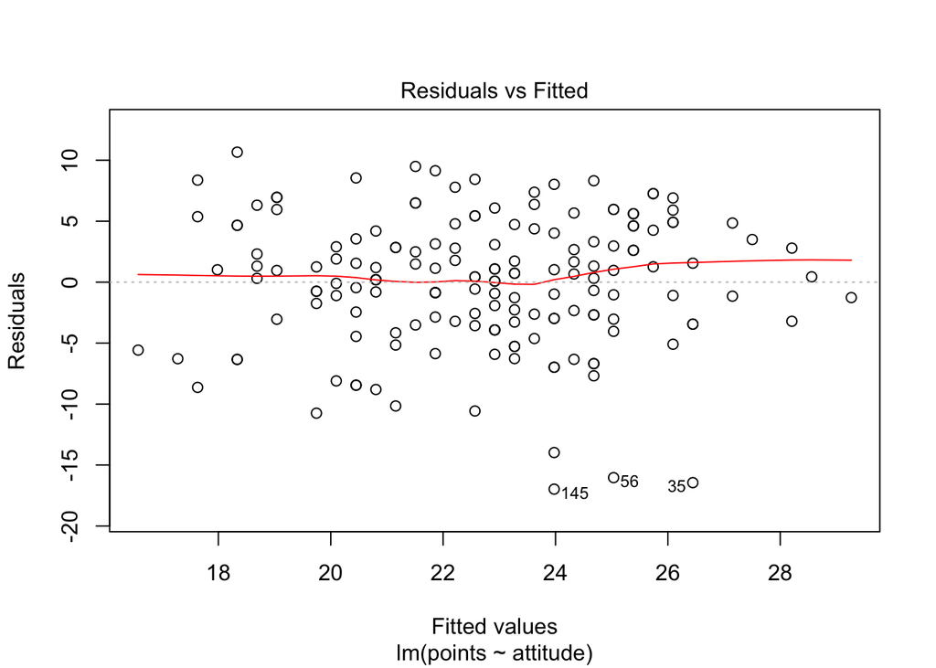

```r
plot(lm3, which = c(1))
```

QQ plot (theoretical quantiles)

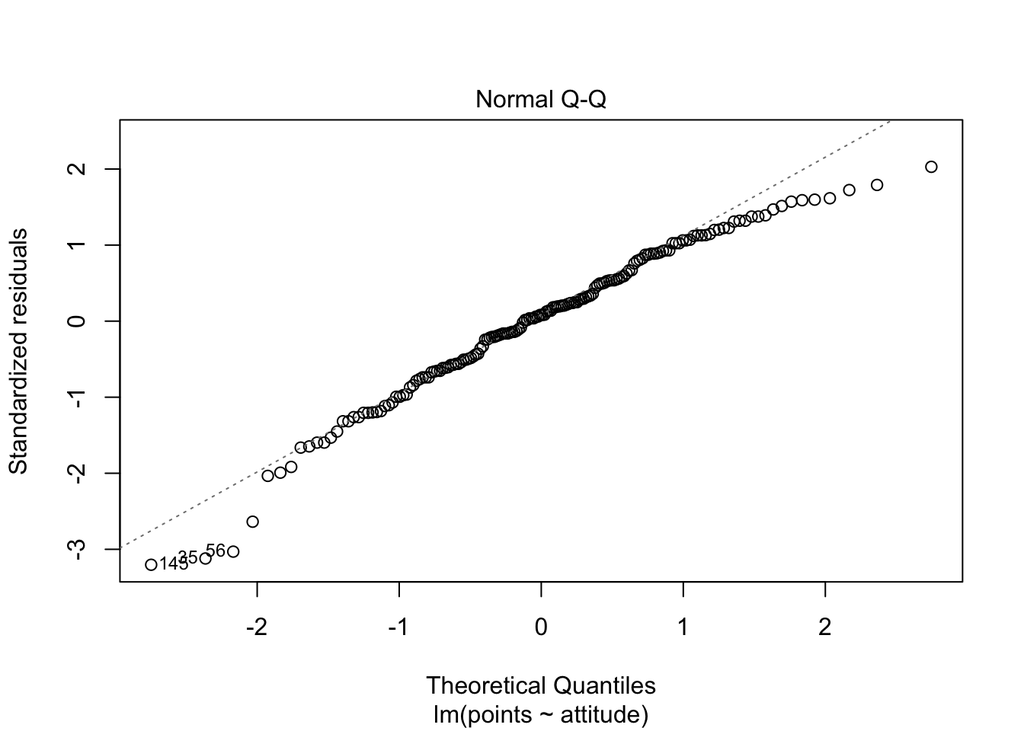

```r
plot(lm3, which = c(2))
```

Residuals vs. Leverage

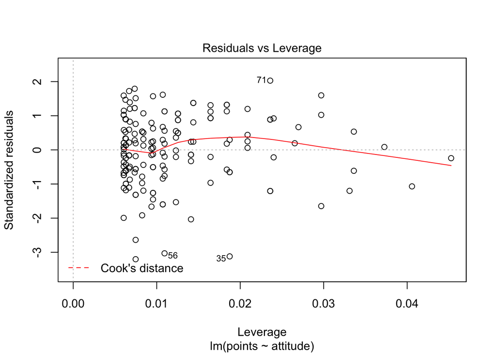

```r
plot(lm3, which = c(5))
```

## Prediction. Train and test sets

1. Determine the number of rows in the dataset

   ```
   n <- nrow(boston_scaled)
   ```

2. Choose randomly 80% of the rows

   ```
   ind <- sample(n,  size = n * 0.8)
   ```

3. Create train set

   ```
   train <- boston_scaled[ind,]
   ```

4. Create test set by substraction the train set

   ```
   test <- boston_scaled[-ind,]
   ```

5. Save the correct classes from test data

   ```
   correct_classes <- test$crime (any variable used for prediction)
   ```

6. Remove this variable from test data

   ```
   test <- dplyr::select(test, -crime)
   ```